# R Programming - Challenge B

Camille Massié, Joanna Mitka, Johanna Joy Obst

23 November 2017

**Link to the Github Repository:** https://github.com/JohannaJoyObst/Challenge-B-2017

## Task 1B - Predicting house prices in Ames, Iowa (continued)

**Step 1:** Random Forest is chosen as the ML technique to predict the house prices in Ames, Iowa. It is an ensemble of supervised learning methods that creates a multiple of decision trees based on random selection of data and of variables to conduct classification, regression or other tasks. Finally it predicts the class of a dependent variables based on many decision trees.

The base of Random Forest, the concept of decision trees is the concept of an algorithm to split the dataset sequentially by a number of rules, depending on the independent variables, such that the class (the dependent variable) can be predicted. To that end, certain criteria, such as the information gain for categorical variables or the gini index for continuous variables, are used to decide at each nodes which attribute is the best to use to split the dataset. Then, the dataset is split according to that established rule, the tree is grown and for each subtree, a new criterion is chosen and a new split conducted.

Random Forest applies this procedure multiple times. Each time, it selects randomly a number of features out of all independent variables and creates a decision tree with them. It then predicts the target by applying the rules of each randomly created decision tree to the test features, counts the votes for each prediction and choses the target with the most votes as the final prediction.

**Step 2:** As in Challenge A, we remove the variables that have more than 10% missing observations. To ensure that the same variables are eliminated in both the training and the test dataset, we merge both datasets, eliminate the variables and resplit the datasets according to the Id as they were split before.

Then, the Random Forest technique is trained on the training data.

**Step 3:** The predictions are compared to the predictions of the linear regression made in Challenge A.

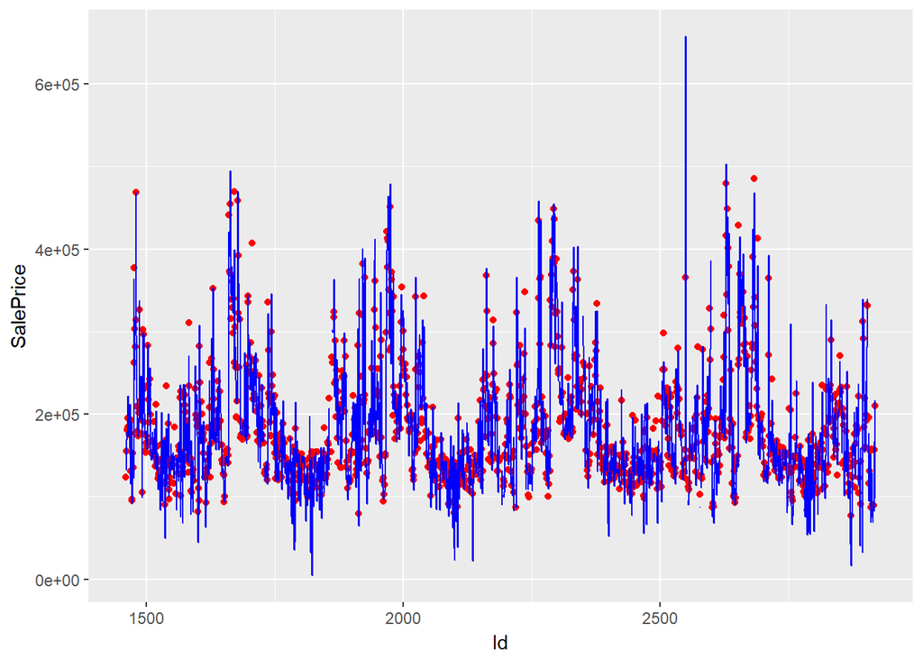

As can be seen from the graph above, the predictions made using linear regression (in blue) and Random Forest (in red) are very similar.

## Task 2B - Overfitting in Machine Learning (continued)

**Step 1 and 2:** We estimate a low and a high flexibility local linear model on the training data. We plot the two regression lines for a better legibility.

Estimation of the low flexibility local linear model:

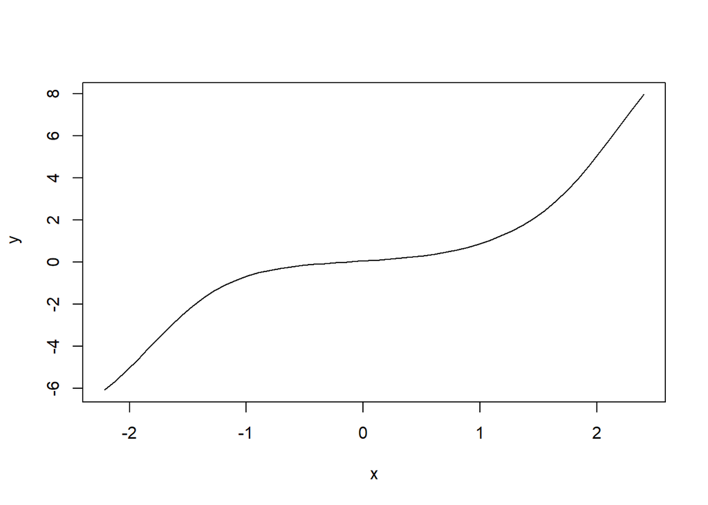

Estimation of the high flexibility local linear model:

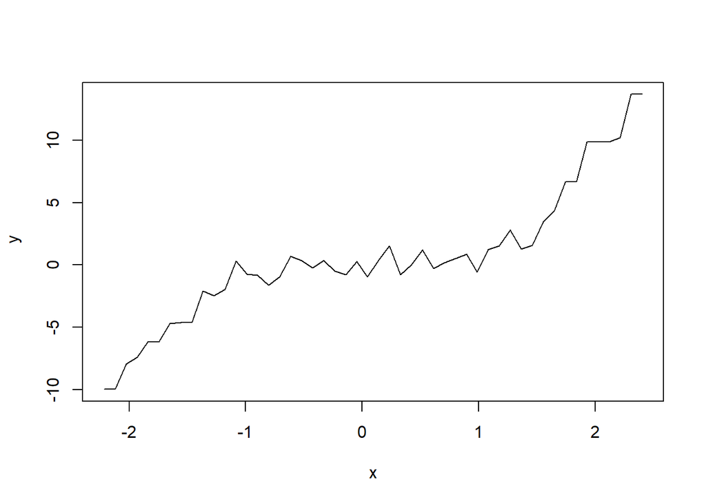

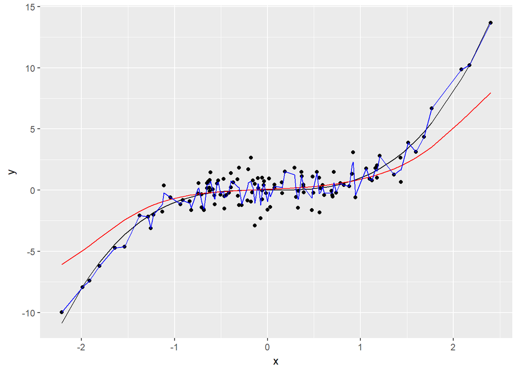

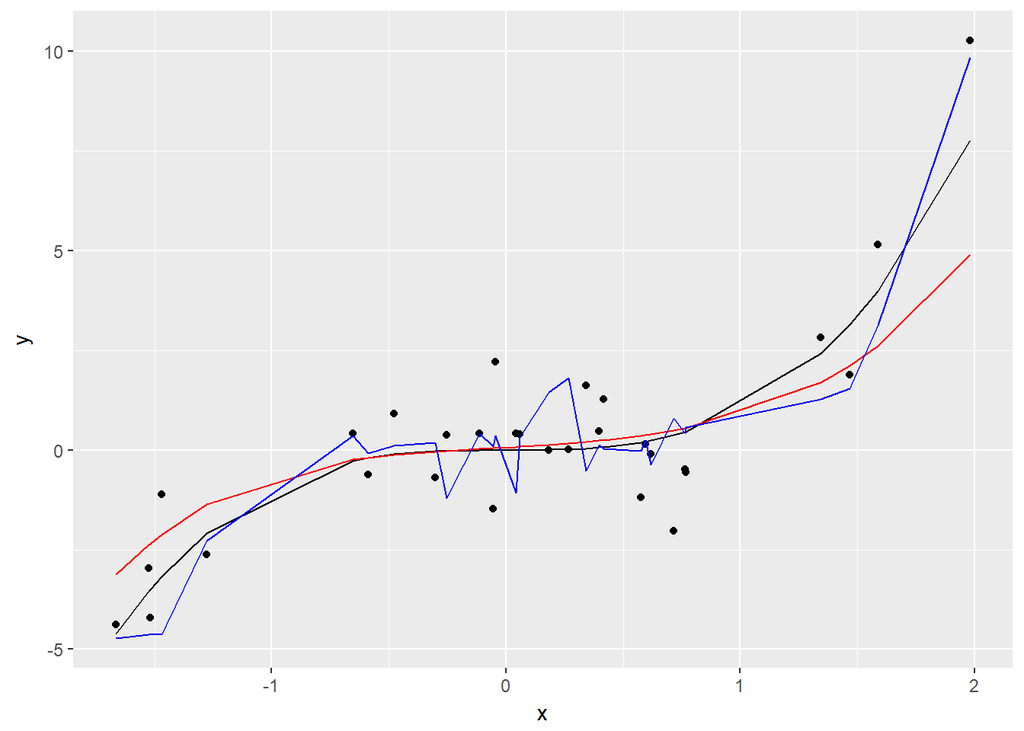

**Step 6:** We create a vector of bandwidth that we call x0. This vector contains 491 elements.

**Step 7:** We create a function which runs a npreg taking each bandwidth of x0 as the bandwidth for the regression on the training data.

**Step 8 and 9:** We create a loop that first computes the predicted values for each np regression (in Step 7) and second computes the MSE from all these predicted values. We do this on the training data (Step 8) and on the test data (Step 9).

**Step 10:** We plot the two MSE (on the y-axis) in function of the bandwidths (on the x-axis). The blue line refers to the MSE from the training data and the orange one to those from the test data. See appendix 5.

Therefore we observe that the MSE are an increasing function of the bandwidth on the training data. However, the MSE on the test data are not a monotonic function of the bandwidth. First they are decreasing with the bandwidth and then they increase as the bandwidth increases.

In our case, the two curves do not intersect event though they are supposed to. Anyway, the MSE from the test data is always higher than those from the train data. It might be because the training data contains more observations as the MSE are a decreasing function of the number of observations in the data, ie n.

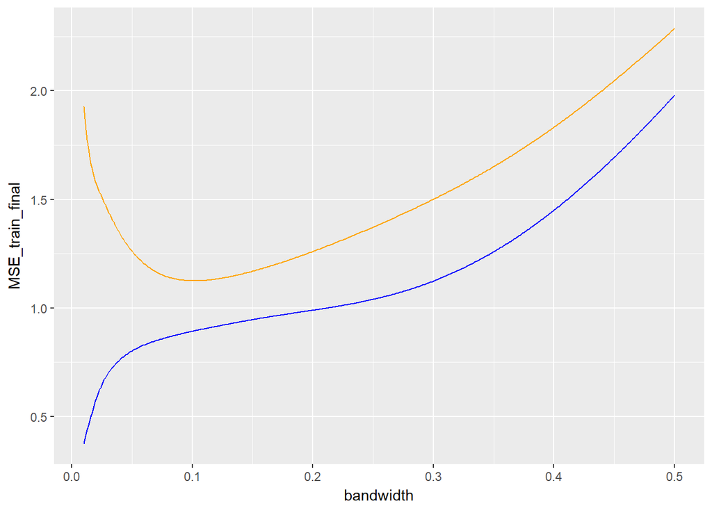

## Task 3B - Privacy regulation compliance in France

**Step 1:** We import of the CNIL data.

**Step 2:** Because departments in France are identified only by the first two digits of the poscode, we extract only those 2 in the Code_Postal column. Then we create a table with number of organizations per department.

**Step 3:** To make it faster to process, we have used Excel to delete columns that are not necessary to merge. New dataset consists of the SIREN, date and the size of the company expressed by the number of eployees (EFENCENT). However, we still have to manage with a large number of the rows. Because we don’t have enough RAM on our PCs, we decide to use an ff package. Its usage provides data structures that are stored on the disc, acting as if they were in the memory. Only necessary parts of the data are mapped into main memory. We start working with a dataset with deleting duplicated rows, concerning the SIREN column.This step left us having only one information about the size for each SIREN number. Now it is possible to merge the information from filteredSirc into the CNIL data.

**Step 4:** We plot the histogram of the size of companies that nominated a CIL. The histogram exposes having many missing in our data. It becomes clear that most of the companies from our dataset employ 0 or 1 employees. There are only very few companies that have many employees.

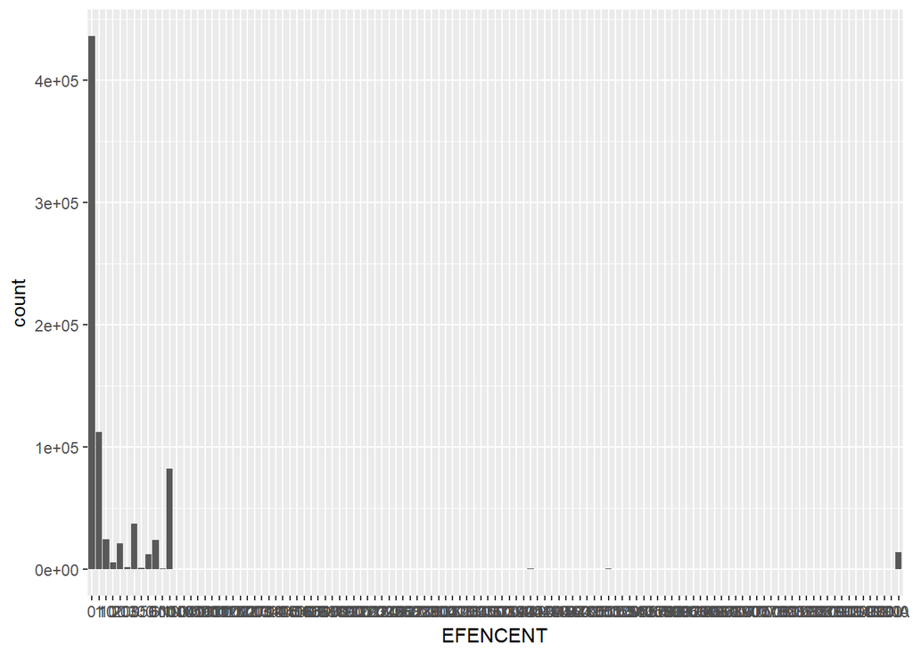

The time needed to run all the commands in task 3 is the following:

```
## Time difference of 19.50248 secs
```

## Sources:

Dataaspirant. 2017. *How the Random Forest Algorithm works in Machine Learning.* Retrieved from: http://dataaspirant.com/2017/05/22/random-forest-algorithm-machine-learing/ (02/12/2017)

Udemy. 2017. *Beginner to Advanced Guide on Machine Learning with R.* Retrieved from: https://www.udemy.com/beginner-to-advanced-guide-on-machine-learning-with-r-tool/learn/v4/overview (29/11/2017).